# Modul Pra-Lokakarya Analisis Data Sensoris

Sensolution.ID

2018-12-13

## Sekilas tentang R

[R](https://www.r-project.org/) merupakan bahasa pemrograman yang khusus diperuntukan untuk kalkulasi dan statistik. Saat ini R sangat populer khususnya di bidang Sains Data dikarenakan kemampuan dan fleksibilitasnya dalam mengolah data. R merupakan bahasa yang sangat menguntungkan untuk bidang ilmu sensoris dikarenakan telah tersedia beberapa paket khusus untuk analisis data sensoris, seperti misalnya `sensR` dan `SensoMineR`. Selain itu juga terdapat banyak paket penunjang lainnya seperti `crossdes`, `BradleyTerry2`, dan `FactoMineR`. Dikarenakan kehandalaannya, R digunakan sebagai mesin kalkulasi oleh beberapa piranti analisis data sensoris komersial.

### Cara memasang R

R didistribusikan perangkat lunak bebas dan sumber terbuka (FLOSS - Free/Libre Open Source Software) sehingga dapat dipergunakan serta dimodifikasi secara bebas. R tersedia untuk sistem operasi GNU/Linux, (Mac) OS X, dan Windows dan dapat diunduh di cran.r-project.org. Pengguna Windows dapat mengunduh dengan cara klik pada bagian ‘Download R for Windows’, kemudian pilih opsi ‘base’, dan terakhir klik ‘Download R 3.5.1 for Windows’. Sebagai alternatif, Anda dapat langsung mengunduh menggunakan pranala [ini](https://cran.r-project.org/bin/windows/base/R-3.5.1-win.exe). Pengguna GNU/Linux dapat mengunduh melalui repositori distribusi masing-masing, sedangkan pengguna (Mac) OS X dapat mengunduh R melalui pranala [ini](https://cran.r-project.org/bin/macosx/R-3.5.1.pkg). Instalasi dilakukan dengan cara klik ganda pada penginstal dan kemudian mengikuti panduan pemasangan yang tersedia.

### Cara memasang IDE RStudio

Pada prinsipnya Anda dapat langsung menggunakan R setelah melakukan pemasangan. Jika Anda pengguna Windows, Anda dapat menggunakan R melalui RGUI yang otomatis terpasang saat pemasangan R. Sedangkan untuk pengguna GNU/Linux atau (Mac) OS X, R dapat digunakan melalui terminal dengan cara mengetik `R`.

Meskipun R dapat langsung digunakan menggunakan RGUI atau terminal, fitur yang tersedia sangat terbatas. Oleh karena itu, tersedia berbagai *Integrated Development Environtment* (IDE) untuk menunjang penggunaan R, msalnya Tinn-R, RKward, RStudio, dan lainnya. Kami merekomendasikan RStudio sebagai pilihan IDE dikarenakan fiturnya sangat lengkap dan masih aktif dikembangkan oleh tim pengembangnya.

[RStudio](https://rstudio.com) tersedia dalam versi gratis dan komersial serta dapat diunduh pada laman [ini](https://www.rstudio.com/products/rstudio/download/). RStudio dapat dipasang pada sistem operasi GNU/Linux, (Mac) OS X, dan Windows. Berikut merupakan tampilan dari RStudio:

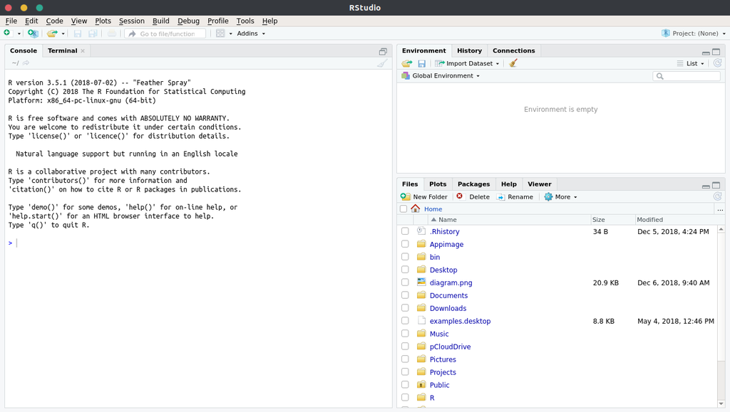

Tampilan RStudio

### Cara memasang paket di R

Paket merupakan ekstensi yang dapat meningkatkan fungsionalitas dari R. Sebelumnya telah disinggung nama beberapa paket yang bermanfaat untuk analisis data sensoris. Paket-paket tersebut dapat dipasang dengan cara menjalankan kode berikut pada konsol RStudio:

- Pemasangan paket satu per satu

```r
install.packages("nama_paket")
```

- Pemasangan paket sekaligus

```r
install.packages(c("crossdes", "BradleyTerry2", "sensR", "FactoMineR", "SensoMineR"))
```

Kami merekomendasikan untuk menuliskan kode R dalam bentuk skrip (disebut sebagai *R Script*) dan kemudian menjalankannya dibandingkan langsung menjalankan pada konsol. Tujuannya adalah agar kode tersebut dapat disimpan, dipelajari, dan digunakan pada waktu lainnya. *R Script* dapat dibuat dengan cara klik `File - New File - R Script` atau menekan kombinasi `Ctrl+Shift+N`. Silakan salin kode pemasangan paket diatas pada skrip, kemudian menjalankannya dengan cara klik`Run` (Ctrl+Enter).

[figure not shown]

Setelah terpasang, paket tambahan harus diaktifkan setiap sebelum digunakan dengan cara menjalankan kode`library(name_of_package)`. Sehingga untuk menjalankan semua paket yang diperlukan, maka jalankan kode berikut:

```r
library(crossdes)
library(BradleyTerry2)
library(sensR)
library(FactoMineR)
library(SensoMineR)
```

## Rekomendasi sebelum lokakarya

Sebelum workshop dilaksanakan, Anda direkomendasikan untuk mempelajari hal-hal dasar mengenai R (apabila ini merupakan pertama kali Anda akan menggunakan R). Salah satu cara efektif untuk belajar R adalah **“Belajar R dengan menggunakan R”**. Berikut merupakan rekomendasi dari kami untuk belajar R dengan menggunakan R:

- Pasang paket `swirl` dengan cara `install.packages("swirl")`
- Setelah terpasang, jalankan `library(swirl)` pada konsol RStudio
- Jalankan `swirl()` dan ikuti instruksi yang diberikan
- Pasang dan ikuti materi “R programming”, khususnya topik 1 hingga 7
- Anda dapat memasang dan mengikuti materi lainnya dengan cara mengikuti instruksi pada pranala [ini](https://github.com/swirldev/swirl_courses).

## Sekilas tentang SenseHub

SenseHub merupakan aplikasi web terintegrasi untuk analisis sensoris yang dikembangkan oleh Sensolution.ID. SenseHub dikembangkan dengan basis bahasa R dan tersedia dalam bentuk aplikasi web, sehingga dapat diakses dengan menggunakan peramban tanpa harus dipasang pada komputer.

[figure not shown]

Tampilan SenseHub

### Fitur SenseHub

| Kategori | Fitur |
| --- | --- |
| Rancangan penelitian | Percangan penelitian (William Latin Square Design) |
| Kinerja panel | Pengujian kinerja panel (grup), penujian kinerja panelis (individu) |
| Uji diskriminatif | 2-Alternatives Force Choice (2AFC), 3-Alternatives Force Choice (3AFC), Duo-Trio, Triangle, Tetrad, Hexad, Two-out-of-Five |
| Uji deskriptif | Quantitative Descriptive Analysis (QDA), Flash Profiling (FP), Free-Choice Profiling (FCP), Rate-all-that-Apply (RATA), Check-all-that-Apply (CATA), RATA as CATA, Sorting Task, Napping |
| Uji afektif | Acceptance test, Paired Preference, Multiple Paired Preference, Preference Ranking, Hedonic Rating, Internal Preference Mapping (MDPREF) |
| Pemicu kesukaan | External Preference Mapping (PREFMAP) |
| Diagnosa atribut | Just-about-Right (JAR) |
| Produk ideal | Ideal Profile Method (IPM) |

*Catatan: fitur SenseHub akan terus ditambahkan dan disempurnakan sesuai dengan perkembangan metodologi dalam ilmu sensoris.*

### Versi

- SenseHub - Basic merupakan versi demo dengan fitur yang terbatas. SenseHub - Basic dapat diakses di s.id/sensehub_basic
- SenseHub - Pro merupakan versi penuh dengan fitur lengkap. SenseHub - Pro dapat diakses di sensehub.sensolution.id

## Penutup

Pada saat lokakarya akan digunakan aplikasi R dan SenseHub untuk menyelesaikan studi kasus. Oleh karena itu, sangat diharapkan Anda telah berhasil memasang R, RStudio, beserta paket-paket yang diperlukan sebelum lokakarya dilaksanakan.

Anda akan diberikan akses untuk SenseHub Pro selama lokakarya berlangsung. Demi kepentingan itu, kami memerlukan data nama beserta email yang Anda miliki untuk kelancaran akses ke SenseHub Pro tersebut. Data yang Anda berikan juga akan digunakan untuk penerbitan sertifikat. Anda dapat mengisi informasi tersebut melalui formulir [ini](https://goo.gl/forms/MXoUBHA9RmzzPC1v2).

Terakhir, silakan bawa laptop beserta *charger* demi kelancaran saat lokakarya berlangsung. Pastikan Anda memiliki koneksi internet saat lokakarya dilaksanakan. Jangan ragu untuk mengubungi surel info@sensolution.id jika Anda memiliki pertanyaan atau kendala. Salam hangat dan sampai jumpa!

[figure not shown]